# Analysis of Bike Sharing Rides with Bay Wheels Data

## Preliminary Wrangling

> Bay Wheels is a bike sharing service available throughout Bay Area of west coast USA. It is a affordible and accessible way of transportation. The company went through several name changes and acquisitions. It started as in August 2013 as Bay Area Bike Share. Later it was re-launched as Ford GoBike in a partnership with Ford Motor Company. 2017. In June 2019 renamed to Bay Wheels after acquisition by Lyft. Bay Wheels system currently has over 2,600 bicycles in 262 stations across San Francisco, East Bay and San Jose. Rides are available to people through Bay Wheels subscription and Lyft app.

> My motivation for this project is to expand the exploratory and explanatory data visualization skills by analyzing bike sharing trends by location in Bay Area: San Francisco, Oakland, San Jose. My goal is to practice exploratory data visualization during the process of data wrangling to uncover interesting features of the dataset and to find problems that must be cleaned. My second goal is to apply explanatory data visualization techniques to comunicate my findings about different bike sahring trends for San Francisco, Oakland and San Jose.

Bay Wheels makes its data avalable here: https://www.lyft.com/bikes/bay-wheels/system-data

```python
# import all packages and set plots to be embedded inline
import numpy as np
import pandas as pd
import matplotlib.pyplot as plt
from matplotlib.ticker import PercentFormatter
import seaborn as sb

import glob

%matplotlib inline
```

### Collecting and loadig the data

> In order to use the data for this analisys I first had to collect data from the link provided above. The Bay Wheels trip history data was presented in multiple zip folders for each month of the year starting from 2017 through July 2019. I first downloaded each folder and then used glob() function to read each file from the foulder path into a list to later combine it into one dataset.

```python
# load data
# Reference: https://stackoverflow.com/questions/20906474/import-multiple-csv-files-into-pandas-and-concatenate-into-one-dataframe

path = r'gobikeAll' # use your path
all_files = glob.glob(path + "/*.csv")

csv_list = []

for filename in all_files:
    df = pd.read_csv(filename, index_col=None, header=0)
    csv_list.append(df)
```

```python
bike_df = pd.concat(csv_list, axis=0, ignore_index=True)
```

```python
bike_df.to_csv('total_fordgobike_data.csv')
```

```python
df = pd.read_csv('total_fordgobike_data.csv', dtype={"Unnamed:0": int, "bike_id": int, "member_gender": object})
df.head()
```

|  | Unnamed: 0 | Unnamed: 16 | bike_id | bike_share_for_all_trip | duration_sec | end_station_id | end_station_latitude | end_station_longitude | end_station_name | end_time | member_birth_year | member_gender | rental_access_method | start_station_id | start_station_latitude | start_station_longitude | start_station_name | start_time | user_type |
| --- | --- | --- | --- | --- | --- | --- | --- | --- | --- | --- | --- | --- | --- | --- | --- | --- | --- | --- | --- |
| 0 | 0 | NaN | 1035 | No | 598 | 114.0 | 37.764478 | -122.402570 | Rhode Island St at 17th St | 2018-03-01 00:09:45.1870 | 1988.0 | Male | NaN | 284.0 | 37.784872 | -122.400876 | Yerba Buena Center for the Arts (Howard St at ... | 2018-02-28 23:59:47.0970 | Subscriber |
| 1 | 1 | NaN | 1673 | No | 943 | 324.0 | 37.788300 | -122.408531 | Union Square (Powell St at Post St) | 2018-02-28 23:36:59.9740 | 1987.0 | Male | NaN | 6.0 | 37.804770 | -122.403234 | The Embarcadero at Sansome St | 2018-02-28 23:21:16.4950 | Customer |
| 2 | 2 | NaN | 3498 | No | 18587 | 15.0 | 37.795392 | -122.394203 | San Francisco Ferry Building (Harry Bridges Pl... | 2018-02-28 23:30:42.9250 | 1986.0 | Female | NaN | 93.0 | 37.770407 | -122.391198 | 4th St at Mission Bay Blvd S | 2018-02-28 18:20:55.1900 | Customer |
| 3 | 3 | NaN | 3129 | No | 18558 | 15.0 | 37.795392 | -122.394203 | San Francisco Ferry Building (Harry Bridges Pl... | 2018-02-28 23:30:12.4500 | 1981.0 | Male | NaN | 93.0 | 37.770407 | -122.391198 | 4th St at Mission Bay Blvd S | 2018-02-28 18:20:53.6210 | Customer |
| 4 | 4 | NaN | 1839 | Yes | 885 | 297.0 | 37.322980 | -121.887931 | Locust St at Grant St | 2018-02-28 23:29:58.6080 | 1976.0 | Female | NaN | 308.0 | 37.336802 | -121.894090 | San Pedro Square | 2018-02-28 23:15:12.8580 | Subscriber |

```python
df = df.drop(['Unnamed: 0'], axis =1)
```

```python
df = df.drop(['Unnamed: 16'], axis =1)
```

```python
df.tail()
```

|  | bike_id | bike_share_for_all_trip | duration_sec | end_station_id | end_station_latitude | end_station_longitude | end_station_name | end_time | member_birth_year | member_gender | rental_access_method | start_station_id | start_station_latitude | start_station_longitude | start_station_name | start_time | user_type |
| --- | --- | --- | --- | --- | --- | --- | --- | --- | --- | --- | --- | --- | --- | --- | --- | --- | --- |
| 3828127 | 4832 | No | 480 | 324.0 | 37.788300 | -122.408531 | Union Square (Powell St at Post St) | 2019-02-01 00:12:50.0340 | 1996.0 | Male | NaN | 27.0 | 37.788059 | -122.391865 | Beale St at Harrison St | 2019-02-01 00:04:49.7240 | Subscriber |
| 3828128 | 4960 | No | 313 | 66.0 | 37.778742 | -122.392741 | 3rd St at Townsend St | 2019-02-01 00:10:48.5020 | 1984.0 | Male | NaN | 21.0 | 37.789625 | -122.400811 | Montgomery St BART Station (Market St at 2nd St) | 2019-02-01 00:05:34.7440 | Subscriber |
| 3828129 | 3824 | Yes | 141 | 277.0 | 37.333658 | -121.908586 | Morrison Ave at Julian St | 2019-02-01 00:08:27.2200 | 1990.0 | Male | NaN | 278.0 | 37.331932 | -121.904888 | The Alameda at Bush St | 2019-02-01 00:06:05.5490 | Subscriber |
| 3828130 | 5095 | No | 139 | 216.0 | 37.817827 | -122.275698 | San Pablo Ave at 27th St | 2019-02-01 00:07:54.2870 | 1988.0 | Male | NaN | 220.0 | 37.811351 | -122.273422 | San Pablo Ave at MLK Jr Way | 2019-02-01 00:05:34.3600 | Subscriber |
| 3828131 | 1057 | No | 271 | 37.0 | 37.785000 | -122.395936 | 2nd St at Folsom St | 2019-02-01 00:04:52.0580 | 1989.0 | Male | NaN | 24.0 | 37.789677 | -122.390428 | Spear St at Folsom St | 2019-02-01 00:00:20.6360 | Subscriber |

```python
df.shape
```

```
(3828132, 17)
```

### What is the structure of your dataset?

> After collecting and combining all of the bike trip data avalable I have a dataset containing over 3 million entries (rows) and 17 colunmns. Original columns of dataset include following:
- Trip Duration (seconds)
- Start Time and Date
- End Time and Date
- Start Station ID
- Start Station Name
- Start Station Latitude
- Start Station Longitude
- End Station ID
- End Station Name
- End Station Latitude
- End Station Longitude
- Bike ID
- User Type (Subscriber or Customer – “Subscriber” = Member or “Customer” = Casual)
- Member Year of Birth
- Member Gender

> The first observation of columns shows that most variables are categorical in nature ("Member Gender", "User Type"). There is a small number of numeric variables ("Trip Duration"). The dataset also includes interesting variable types releted to time and geographical location which could be usefull for creating new variables but also would requre cleaning.

### What is/are the main feature(s) of interest in your dataset?

> The Bay Wheels stations are available three main areas of the Bay Area: San Francisco, the East Bay, and San Jose. I would like to explore how trends of bike-sharing vary for each of those areas.

### What features in the dataset do you think will help support your investigation into your feature(s) of interest?

> The dataset is not separated by city, therefore the feauture that will help me solve this limitation are the collection of columns containing longitude and latitude of bike stations.

```python
# check variables of dataset programatically
list(df)
```

```
['bike_id',
 'bike_share_for_all_trip',
 'duration_sec',
 'end_station_id',
 'end_station_latitude',
 'end_station_longitude',
 'end_station_name',
 'end_time',
 'member_birth_year',
 'member_gender',
 'rental_access_method',
 'start_station_id',
 'start_station_latitude',
 'start_station_longitude',
 'start_station_name',
 'start_time',
 'user_type']
```

```python
# check datatypes
df.dtypes
```

```
bike_id                      int64
bike_share_for_all_trip     object
duration_sec                 int64
end_station_id             float64
end_station_latitude       float64
end_station_longitude      float64
end_station_name            object
end_time                    object
member_birth_year          float64
member_gender               object
rental_access_method        object
start_station_id           float64
start_station_latitude     float64
start_station_longitude    float64
start_station_name          object
start_time                  object
user_type                   object
dtype: object
```

#### Exploring and cleaning "member_gender column.

```python
df.member_gender.isnull().sum()
```

```
276194
```

```python
df.member_gender.value_counts()
```

```
Male      2614403
Female     851543
Other       57986
M           19885
F            5076
?            2589
O             456
Name: member_gender, dtype: int64
```

```python
# drop rows with missing gender and with question mark
df['member_gender'] = df['member_gender'].replace('?', np.nan)
df = df.dropna(axis=0, subset=['member_gender'])
```

```python
df.member_gender.isnull().sum()
```

```
0
```

```python
# clean value names for gender column
df['member_gender'][df['member_gender'].str.match('M')] = 'Male'
df['member_gender'][df['member_gender'].str.match('F')] = 'Female'
df['member_gender'][df['member_gender'].str.match('O|\?')] = 'Other'
```

```python
# test to make sure only meaningfull gender remains
df.member_gender.value_counts()
```

```
Male      2634288
Female     856619
Other       58442
Name: member_gender, dtype: int64
```

#### Explore and clean end time and start time columns

```python
# convert start and end dates of trips to date/time type
df['start_time'] = pd.to_datetime(df['start_time'])
df['end_time'] = pd.to_datetime(df['end_time'])
df = df.sort_values(by='start_time')
```

```python
df.dtypes
```

```
bike_id                             int64
bike_share_for_all_trip            object
duration_sec                        int64
end_station_id                    float64
end_station_latitude              float64
end_station_longitude             float64
end_station_name                   object
end_time                   datetime64[ns]
member_birth_year                 float64
member_gender                      object
rental_access_method               object
start_station_id                  float64
start_station_latitude            float64
start_station_longitude           float64
start_station_name                 object
start_time                 datetime64[ns]
user_type                          object
dtype: object
```

```python
# test if data was sorted
# dataframe now strts with data for 2017
df.head(2)
```

|  | bike_id | bike_share_for_all_trip | duration_sec | end_station_id | end_station_latitude | end_station_longitude | end_station_name | end_time | member_birth_year | member_gender | rental_access_method | start_station_id | start_station_latitude | start_station_longitude | start_station_name | start_time | user_type |
| --- | --- | --- | --- | --- | --- | --- | --- | --- | --- | --- | --- | --- | --- | --- | --- | --- | --- |
| 1185878 | 240 | NaN | 424 | 48.0 | 37.782411 | -122.392706 | 2nd St at S Park St | 2017-06-28 09:54:41.187 | 1985.0 | Female | NaN | 21.0 | 37.789625 | -122.400811 | Montgomery St BART Station (Market St at 2nd St) | 2017-06-28 09:47:36.347 | Subscriber |
| 1185879 | 669 | NaN | 366 | 59.0 | 37.774814 | -122.418954 | S Van Ness Ave at Market St | 2017-06-28 09:53:47.715 | 1981.0 | Male | NaN | 58.0 | 37.776619 | -122.417385 | Market St at 10th St | 2017-06-28 09:47:41.664 | Subscriber |

```python
# dataframe ends with 2019 data
df.tail(2)
```

|  | bike_id | bike_share_for_all_trip | duration_sec | end_station_id | end_station_latitude | end_station_longitude | end_station_name | end_time | member_birth_year | member_gender | rental_access_method | start_station_id | start_station_latitude | start_station_longitude | start_station_name | start_time | user_type |
| --- | --- | --- | --- | --- | --- | --- | --- | --- | --- | --- | --- | --- | --- | --- | --- | --- | --- |
| 1381861 | 1891 | No | 167 | 75.0 | 37.773793 | -122.421239 | Market St at Franklin St | 2019-08-01 00:01:46.728 | 1984.0 | Male | NaN | 58.0 | 37.776619 | -122.417385 | Market St at 10th St | 2019-07-31 23:58:59.171 | Subscriber |
| 1381862 | 3420 | No | 155 | 75.0 | 37.773793 | -122.421239 | Market St at Franklin St | 2019-08-01 00:01:46.244 | 1988.0 | Male | NaN | 58.0 | 37.776619 | -122.417385 | Market St at 10th St | 2019-07-31 23:59:10.696 | Subscriber |

#### Explore and clean the user type column

```python
df.user_type.isnull().sum()
```

```
0
```

```python
df.user_type.value_counts()
```

```
Subscriber    3156227
Customer       393122
Name: user_type, dtype: int64
```

#### Explore and clean the rental access method column

```python
df.rental_access_method.isnull().sum()
```

```
3546565
```

```python
df.rental_access_method.value_counts()
```

```
app        2297
clipper     487
Name: rental_access_method, dtype: int64
```

```python
df['rental_access_method'] = df['rental_access_method'].fillna(value= "other")
```

```python
df.rental_access_method.value_counts()
```

```
other      3546565
app           2297
clipper        487
Name: rental_access_method, dtype: int64
```

#### Explore and clean memeber birth year column

```python
df.member_birth_year.isnull().sum()
```

```
442
```

```python
df = df.dropna(axis=0, subset=['member_birth_year'])
```

```python
# create column for age of riders and calculate age from the birth yaer
df['age'] = 2019 - df['member_birth_year']
```

```python
df.age.isnull().sum()
```

```
0
```

```python
# convert age into int data type
df['age'] =( df['age']).astype(int)
```

```python
df.describe()
```

|  | bike_id | duration_sec | end_station_id | end_station_latitude | end_station_longitude | member_birth_year | start_station_id | start_station_latitude | start_station_longitude | age |
| --- | --- | --- | --- | --- | --- | --- | --- | --- | --- | --- |
| count | 3.548907e+06 | 3.548907e+06 | 3.521290e+06 | 3.548907e+06 | 3.548907e+06 | 3.548907e+06 | 3.521429e+06 | 3.548907e+06 | 3.548907e+06 | 3.548907e+06 |
| mean | 5.902781e+03 | 7.725807e+02 | 1.225429e+02 | 3.776748e+01 | -1.223493e+02 | 1.983376e+03 | 1.245472e+02 | 3.776754e+01 | -1.223504e+02 | 3.562373e+01 |
| std | 4.310510e+04 | 1.951578e+03 | 1.047699e+02 | 1.342511e-01 | 3.113841e-01 | 1.042481e+01 | 1.050945e+02 | 1.058976e-01 | 1.593233e-01 | 1.042481e+01 |
| min | 1.000000e+01 | 6.000000e+01 | 3.000000e+00 | 0.000000e+00 | -1.224737e+02 | 1.878000e+03 | 3.000000e+00 | 0.000000e+00 | -1.224737e+02 | 1.800000e+01 |
| 25% | 1.299000e+03 | 3.460000e+02 | 3.000000e+01 | 3.777106e+01 | -1.224107e+02 | 1.978000e+03 | 3.600000e+01 | 3.777106e+01 | -1.224117e+02 | 2.800000e+01 |
| 50% | 2.517000e+03 | 5.450000e+02 | 8.900000e+01 | 3.778107e+01 | -1.223971e+02 | 1.986000e+03 | 9.000000e+01 | 3.778107e+01 | -1.223974e+02 | 3.300000e+01 |
| 75% | 3.678000e+03 | 8.410000e+02 | 1.930000e+02 | 3.779659e+01 | -1.222894e+02 | 1.991000e+03 | 1.950000e+02 | 3.779625e+01 | -1.222880e+02 | 4.100000e+01 |
| max | 9.969630e+05 | 8.628100e+04 | 4.430000e+02 | 4.551000e+01 | 0.000000e+00 | 2.001000e+03 | 4.430000e+02 | 4.551000e+01 | 0.000000e+00 | 1.410000e+02 |

#### Explore and clean trip duration column

```python
df.duration_sec.isnull().sum()
```

```
0
```

```python
# create additional column for trip duration in minutes
df['duration_min'] = (df['duration_sec']/60).astype(int)
```

```python
df.head()
```

|  | bike_id | bike_share_for_all_trip | duration_sec | end_station_id | end_station_latitude | end_station_longitude | end_station_name | end_time | member_birth_year | member_gender | rental_access_method | start_station_id | start_station_latitude | start_station_longitude | start_station_name | start_time | user_type | age | duration_min |
| --- | --- | --- | --- | --- | --- | --- | --- | --- | --- | --- | --- | --- | --- | --- | --- | --- | --- | --- | --- |
| 1185878 | 240 | NaN | 424 | 48.0 | 37.782411 | -122.392706 | 2nd St at S Park St | 2017-06-28 09:54:41.187 | 1985.0 | Female | other | 21.0 | 37.789625 | -122.400811 | Montgomery St BART Station (Market St at 2nd St) | 2017-06-28 09:47:36.347 | Subscriber | 34 | 7 |
| 1185879 | 669 | NaN | 366 | 59.0 | 37.774814 | -122.418954 | S Van Ness Ave at Market St | 2017-06-28 09:53:47.715 | 1981.0 | Male | other | 58.0 | 37.776619 | -122.417385 | Market St at 10th St | 2017-06-28 09:47:41.664 | Subscriber | 38 | 6 |
| 1185880 | 117 | NaN | 188 | 48.0 | 37.782411 | -122.392706 | 2nd St at S Park St | 2017-06-28 09:52:55.338 | 1984.0 | Male | other | 25.0 | 37.787522 | -122.397405 | Howard St at 2nd St | 2017-06-28 09:49:46.377 | Subscriber | 35 | 3 |
| 1185873 | 77 | NaN | 1201 | 9.0 | 37.798572 | -122.400869 | Broadway at Battery St | 2017-06-28 10:11:00.359 | 1985.0 | Male | other | 81.0 | 37.775880 | -122.393170 | Berry St at 4th St | 2017-06-28 09:50:59.175 | Subscriber | 34 | 20 |
| 1185877 | 316 | NaN | 431 | 321.0 | 37.780146 | -122.403071 | 5th at Folsom | 2017-06-28 10:03:51.090 | 1973.0 | Male | other | 66.0 | 37.778742 | -122.392741 | 3rd St at Townsend St | 2017-06-28 09:56:39.631 | Subscriber | 46 | 7 |

## Univariate Exploration

```python
# make a CSV file to save results of cleaning
df.to_csv('clean_df.csv', index=False)
```

```python
df_clean = pd.read_csv('clean_df.csv')
```

I have noticed that date/time object type did not transfer into new dataset, have to convert again

```python
# convert start and end dates of trips to date/time type
df_clean['start_time'] = pd.to_datetime(df_clean['start_time'])
df_clean['end_time'] = pd.to_datetime(df_clean['end_time'])
df_clean = df_clean.sort_values(by='start_time')
```

```python
df_clean.head()
```

|  | bike_id | bike_share_for_all_trip | duration_sec | end_station_id | end_station_latitude | end_station_longitude | end_station_name | end_time | member_birth_year | member_gender | rental_access_method | start_station_id | start_station_latitude | start_station_longitude | start_station_name | start_time | user_type | age | duration_min |
| --- | --- | --- | --- | --- | --- | --- | --- | --- | --- | --- | --- | --- | --- | --- | --- | --- | --- | --- | --- |
| 0 | 240 | NaN | 424 | 48.0 | 37.782411 | -122.392706 | 2nd St at S Park St | 2017-06-28 09:54:41.187 | 1985.0 | Female | other | 21.0 | 37.789625 | -122.400811 | Montgomery St BART Station (Market St at 2nd St) | 2017-06-28 09:47:36.347 | Subscriber | 34 | 7 |
| 1 | 669 | NaN | 366 | 59.0 | 37.774814 | -122.418954 | S Van Ness Ave at Market St | 2017-06-28 09:53:47.715 | 1981.0 | Male | other | 58.0 | 37.776619 | -122.417385 | Market St at 10th St | 2017-06-28 09:47:41.664 | Subscriber | 38 | 6 |
| 2 | 117 | NaN | 188 | 48.0 | 37.782411 | -122.392706 | 2nd St at S Park St | 2017-06-28 09:52:55.338 | 1984.0 | Male | other | 25.0 | 37.787522 | -122.397405 | Howard St at 2nd St | 2017-06-28 09:49:46.377 | Subscriber | 35 | 3 |
| 3 | 77 | NaN | 1201 | 9.0 | 37.798572 | -122.400869 | Broadway at Battery St | 2017-06-28 10:11:00.359 | 1985.0 | Male | other | 81.0 | 37.775880 | -122.393170 | Berry St at 4th St | 2017-06-28 09:50:59.175 | Subscriber | 34 | 20 |
| 4 | 316 | NaN | 431 | 321.0 | 37.780146 | -122.403071 | 5th at Folsom | 2017-06-28 10:03:51.090 | 1973.0 | Male | other | 66.0 | 37.778742 | -122.392741 | 3rd St at Townsend St | 2017-06-28 09:56:39.631 | Subscriber | 46 | 7 |

I will start by looking at the count of categorical variables of the dataset

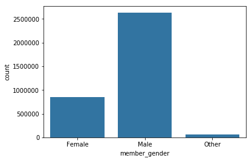

```python
# count by gender of riders
base = sb.color_palette()[0]
sb.countplot(data = df_clean, x = 'member_gender', color = base);
```

```python
df_clean.member_gender.value_counts()
```

[output not shown]

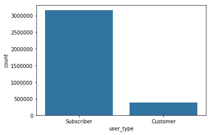

```python
# count of user types
sb.countplot(data = df_clean, x = 'user_type', color = base);
```

```python
df_clean.user_type.value_counts()
```

[output not shown]

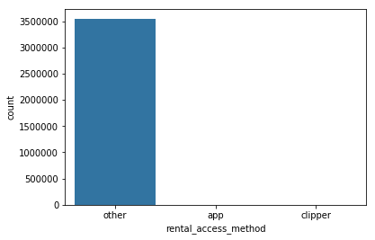

```python
# count of access method
sb.countplot(data = df_clean, x = 'rental_access_method', color = base);
```

```python
df_clean.rental_access_method.value_counts()
```

[output not shown]

I use box polt to explore numeric variable "age" that I created in the process of cleaning. Here I start to notice a larrge number of outliers. The plot helps to discover that the dataset contains entries of unrealistic age over 100 years. This is first issue that was discovered by exploratory visual of the dataset that requires additional cleaning.

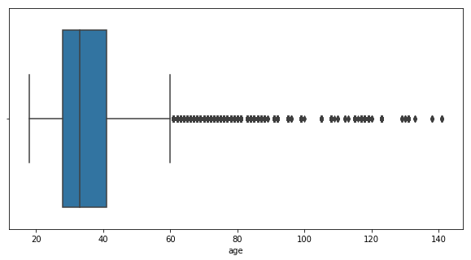

```python
# box plot of age variable shows outliers
plt.figure(figsize=(10,5))
sb.boxplot(data = df_clean, x = 'age', color = base);
```

```python
df_clean.age.describe()
```

```
count    3.548907e+06
mean     3.562373e+01
std      1.042481e+01
min      1.800000e+01
25%      2.800000e+01
50%      3.300000e+01
75%      4.100000e+01
max      1.410000e+02
Name: age, dtype: float64
```

```python
# dataset includes unrealistic birth years
df_clean[df_clean['age']>90]
```

|  | bike_id | bike_share_for_all_trip | duration_sec | end_station_id | end_station_latitude | end_station_longitude | end_station_name | end_time | member_birth_year | member_gender | rental_access_method | start_station_id | start_station_latitude | start_station_longitude | start_station_name | start_time | user_type | age | duration_min |
| --- | --- | --- | --- | --- | --- | --- | --- | --- | --- | --- | --- | --- | --- | --- | --- | --- | --- | --- | --- |
| 311 | 1071 | NaN | 600 | 30.0 | 37.776598 | -122.395282 | San Francisco Caltrain (Townsend St at 4th St) | 2017-06-28 17:13:03.048 | 1902.0 | Male | other | 19.0 | 37.788975 | -122.403452 | Post St at Kearny St | 2017-06-28 17:03:02.557 | Subscriber | 117 | 10 |
| 817 | 908 | NaN | 582 | 21.0 | 37.789625 | -122.400811 | Montgomery St BART Station (Market St at 2nd St) | 2017-06-29 09:23:03.903 | 1902.0 | Male | other | 30.0 | 37.776598 | -122.395282 | San Francisco Caltrain (Townsend St at 4th St) | 2017-06-29 09:13:21.617 | Subscriber | 117 | 9 |
| 1193 | 898 | NaN | 613 | 67.0 | 37.776639 | -122.395526 | San Francisco Caltrain Station 2 (Townsend St... | 2017-06-29 17:18:13.382 | 1902.0 | Male | other | 19.0 | 37.788975 | -122.403452 | Post St at Kearny St | 2017-06-29 17:08:00.006 | Subscriber | 117 | 10 |
| 1614 | 271 | NaN | 501 | 21.0 | 37.789625 | -122.400811 | Montgomery St BART Station (Market St at 2nd St) | 2017-06-30 08:32:32.714 | 1902.0 | Male | other | 30.0 | 37.776598 | -122.395282 | San Francisco Caltrain (Townsend St at 4th St) | 2017-06-30 08:24:11.274 | Subscriber | 117 | 8 |
| 2144 | 765 | NaN | 590 | 30.0 | 37.776598 | -122.395282 | San Francisco Caltrain (Townsend St at 4th St) | 2017-06-30 17:15:06.512 | 1902.0 | Male | other | 19.0 | 37.788975 | -122.403452 | Post St at Kearny St | 2017-06-30 17:05:16.219 | Subscriber | 117 | 9 |
| 3869 | 1044 | NaN | 448 | 21.0 | 37.789625 | -122.400811 | Montgomery St BART Station (Market St at 2nd St) | 2017-07-05 09:21:32.460 | 1902.0 | Male | other | 67.0 | 37.776639 | -122.395526 | San Francisco Caltrain Station 2 (Townsend St... | 2017-07-05 09:14:03.495 | Subscriber | 117 | 7 |
| 4162 | 100 | NaN | 567 | 30.0 | 37.776598 | -122.395282 | San Francisco Caltrain (Townsend St at 4th St) | 2017-07-05 16:50:42.683 | 1902.0 | Male | other | 19.0 | 37.788975 | -122.403452 | Post St at Kearny St | 2017-07-05 16:41:15.146 | Subscriber | 117 | 9 |
| 5939 | 350 | NaN | 535 | 21.0 | 37.789625 | -122.400811 | Montgomery St BART Station (Market St at 2nd St) | 2017-07-07 09:24:56.635 | 1902.0 | Male | other | 67.0 | 37.776639 | -122.395526 | San Francisco Caltrain Station 2 (Townsend St... | 2017-07-07 09:16:01.225 | Subscriber | 117 | 8 |
| 6355 | 123 | NaN | 614 | 30.0 | 37.776598 | -122.395282 | San Francisco Caltrain (Townsend St at 4th St) | 2017-07-07 17:18:25.267 | 1902.0 | Male | other | 19.0 | 37.788975 | -122.403452 | Post St at Kearny St | 2017-07-07 17:08:10.893 | Subscriber | 117 | 10 |
| 7476 | 234 | NaN | 425 | 21.0 | 37.789625 | -122.400811 | Montgomery St BART Station (Market St at 2nd St) | 2017-07-10 08:35:37.980 | 1902.0 | Male | other | 67.0 | 37.776639 | -122.395526 | San Francisco Caltrain Station 2 (Townsend St... | 2017-07-10 08:28:32.457 | Subscriber | 117 | 7 |
| 7599 | 270 | NaN | 473 | 45.0 | 37.781752 | -122.405127 | 5th St at Howard St | 2017-07-10 09:15:02.898 | 1902.0 | Female | other | 30.0 | 37.776598 | -122.395282 | San Francisco Caltrain (Townsend St at 4th St) | 2017-07-10 09:07:09.050 | Subscriber | 117 | 7 |
| 8087 | 703 | NaN | 474 | 30.0 | 37.776598 | -122.395282 | San Francisco Caltrain (Townsend St at 4th St) | 2017-07-10 17:14:47.332 | 1902.0 | Male | other | 19.0 | 37.788975 | -122.403452 | Post St at Kearny St | 2017-07-10 17:06:52.630 | Subscriber | 117 | 7 |
| 8116 | 270 | NaN | 484 | 67.0 | 37.776639 | -122.395526 | San Francisco Caltrain Station 2 (Townsend St... | 2017-07-10 17:21:46.558 | 1902.0 | Female | other | 45.0 | 37.781752 | -122.405127 | 5th St at Howard St | 2017-07-10 17:13:42.058 | Subscriber | 117 | 8 |
| 9149 | 674 | NaN | 221 | 185.0 | 37.801858 | -122.265368 | Jackson St at 14th St | 2017-07-11 14:22:58.825 | 1928.0 | Other | other | 7.0 | 37.804562 | -122.271738 | Frank H Ogawa Plaza | 2017-07-11 14:19:17.314 | Subscriber | 91 | 3 |
| 9815 | 566 | NaN | 329 | 7.0 | 37.804562 | -122.271738 | Frank H Ogawa Plaza | 2017-07-11 22:00:04.914 | 1928.0 | Other | other | 186.0 | 37.801319 | -122.262642 | Lakeside Dr at 14th St | 2017-07-11 21:54:35.739 | Subscriber | 91 | 5 |
| 10220 | 281 | NaN | 515 | 21.0 | 37.789625 | -122.400811 | Montgomery St BART Station (Market St at 2nd St) | 2017-07-12 09:21:48.149 | 1902.0 | Male | other | 67.0 | 37.776639 | -122.395526 | San Francisco Caltrain Station 2 (Townsend St... | 2017-07-12 09:13:12.646 | Subscriber | 117 | 8 |
| 10237 | 768 | NaN | 717 | 321.0 | 37.780146 | -122.403071 | 5th at Folsom | 2017-07-12 09:30:23.538 | 1902.0 | Female | other | 67.0 | 37.776639 | -122.395526 | San Francisco Caltrain Station 2 (Townsend St... | 2017-07-12 09:18:26.124 | Subscriber | 117 | 11 |
| 10779 | 847 | NaN | 497 | 67.0 | 37.776639 | -122.395526 | San Francisco Caltrain Station 2 (Townsend St... | 2017-07-12 17:12:59.762 | 1902.0 | Female | other | 45.0 | 37.781752 | -122.405127 | 5th St at Howard St | 2017-07-12 17:04:41.763 | Subscriber | 117 | 8 |
| 10809 | 914 | NaN | 710 | 30.0 | 37.776598 | -122.395282 | San Francisco Caltrain (Townsend St at 4th St) | 2017-07-12 17:22:01.050 | 1902.0 | Male | other | 19.0 | 37.788975 | -122.403452 | Post St at Kearny St | 2017-07-12 17:10:10.058 | Subscriber | 117 | 11 |
| 11479 | 347 | NaN | 530 | 21.0 | 37.789625 | -122.400811 | Montgomery St BART Station (Market St at 2nd St) | 2017-07-13 08:32:18.048 | 1902.0 | Male | other | 67.0 | 37.776639 | -122.395526 | San Francisco Caltrain Station 2 (Townsend St... | 2017-07-13 08:23:27.145 | Subscriber | 117 | 8 |
| 11705 | 847 | NaN | 509 | 45.0 | 37.781752 | -122.405127 | 5th St at Howard St | 2017-07-13 09:39:47.324 | 1902.0 | Female | other | 67.0 | 37.776639 | -122.395526 | San Francisco Caltrain Station 2 (Townsend St... | 2017-07-13 09:31:18.126 | Subscriber | 117 | 8 |
| 12301 | 714 | NaN | 613 | 67.0 | 37.776639 | -122.395526 | San Francisco Caltrain Station 2 (Townsend St... | 2017-07-13 17:21:08.146 | 1902.0 | Male | other | 19.0 | 37.788975 | -122.403452 | Post St at Kearny St | 2017-07-13 17:10:54.514 | Subscriber | 117 | 10 |
| 13293 | 353 | NaN | 475 | 45.0 | 37.781752 | -122.405127 | 5th St at Howard St | 2017-07-14 11:25:47.597 | 1902.0 | Female | other | 67.0 | 37.776639 | -122.395526 | San Francisco Caltrain Station 2 (Townsend St... | 2017-07-14 11:17:51.764 | Subscriber | 117 | 7 |
| 15818 | 99 | NaN | 438 | 21.0 | 37.789625 | -122.400811 | Montgomery St BART Station (Market St at 2nd St) | 2017-07-17 09:26:31.304 | 1902.0 | Male | other | 66.0 | 37.778742 | -122.392741 | 3rd St at Townsend St | 2017-07-17 09:19:13.087 | Subscriber | 117 | 7 |
| 15868 | 850 | NaN | 612 | 45.0 | 37.781752 | -122.405127 | 5th St at Howard St | 2017-07-17 09:42:47.363 | 1902.0 | Female | other | 67.0 | 37.776639 | -122.395526 | San Francisco Caltrain Station 2 (Townsend St... | 2017-07-17 09:32:34.719 | Subscriber | 117 | 10 |
| 16388 | 1027 | NaN | 582 | 81.0 | 37.775880 | -122.393170 | Berry St at 4th St | 2017-07-17 17:10:38.426 | 1902.0 | Male | other | 19.0 | 37.788975 | -122.403452 | Post St at Kearny St | 2017-07-17 17:00:55.796 | Subscriber | 117 | 9 |
| 16758 | 760 | NaN | 341 | 67.0 | 37.776639 | -122.395526 | San Francisco Caltrain Station 2 (Townsend St... | 2017-07-17 18:47:56.545 | 1902.0 | Female | other | 45.0 | 37.781752 | -122.405127 | 5th St at Howard St | 2017-07-17 18:42:15.375 | Subscriber | 117 | 5 |
| 17176 | 1942 | NaN | 567 | 21.0 | 37.789625 | -122.400811 | Montgomery St BART Station (Market St at 2nd St) | 2017-07-18 08:38:31.297 | 1902.0 | Male | other | 67.0 | 37.776639 | -122.395526 | San Francisco Caltrain Station 2 (Townsend St... | 2017-07-18 08:29:03.518 | Subscriber | 117 | 9 |
| 17411 | 221 | NaN | 432 | 45.0 | 37.781752 | -122.405127 | 5th St at Howard St | 2017-07-18 09:30:00.365 | 1902.0 | Female | other | 67.0 | 37.776639 | -122.395526 | San Francisco Caltrain Station 2 (Townsend St... | 2017-07-18 09:22:47.437 | Subscriber | 117 | 7 |
| 18015 | 1943 | NaN | 545 | 30.0 | 37.776598 | -122.395282 | San Francisco Caltrain (Townsend St at 4th St) | 2017-07-18 17:12:56.037 | 1902.0 | Male | other | 19.0 | 37.788975 | -122.403452 | Post St at Kearny St | 2017-07-18 17:03:50.214 | Subscriber | 117 | 9 |
| ... | ... | ... | ... | ... | ... | ... | ... | ... | ... | ... | ... | ... | ... | ... | ... | ... | ... | ... | ... |
| 3500818 | 904 | No | 596 | 136.0 | 37.754436 | -122.404364 | 23rd St at San Bruno Ave | 2019-07-22 19:34:11.799 | 1896.0 | Other | other | 141.0 | 37.747998 | -122.420219 | Valencia St at Cesar Chavez St | 2019-07-22 19:24:15.412 | Subscriber | 123 | 9 |
| 3500915 | 3718 | No | 513 | 254.0 | 37.880222 | -122.269592 | Vine St at Shattuck Ave | 2019-07-22 19:46:15.969 | 1920.0 | Male | other | 246.0 | 37.869060 | -122.270556 | Berkeley Civic Center | 2019-07-22 19:37:42.405 | Subscriber | 99 | 8 |
| 3502589 | 190 | No | 548 | 364.0 | 37.772000 | -122.389970 | China Basin St at 3rd St | 2019-07-23 08:42:29.440 | 1890.0 | Male | other | 376.0 | 37.760458 | -122.387540 | Illinois St at 20th St | 2019-07-23 08:33:21.096 | Subscriber | 129 | 9 |
| 3506827 | 1574 | No | 798 | 136.0 | 37.754436 | -122.404364 | 23rd St at San Bruno Ave | 2019-07-23 19:50:17.061 | 1896.0 | Other | other | 141.0 | 37.747998 | -122.420219 | Valencia St at Cesar Chavez St | 2019-07-23 19:36:58.602 | Subscriber | 123 | 13 |
| 3507412 | 746 | No | 473 | 81.0 | 37.775880 | -122.393170 | Berry St at 4th St | 2019-07-23 21:46:54.809 | 1890.0 | Male | other | 37.0 | 37.785377 | -122.396906 | 2nd St at Folsom St | 2019-07-23 21:39:01.037 | Subscriber | 129 | 7 |
| 3508857 | 1617 | No | 1091 | 36.0 | 37.783830 | -122.398870 | Folsom St at 3rd St | 2019-07-24 09:14:33.791 | 1900.0 | Male | other | 375.0 | 37.774836 | -122.446546 | Grove St at Masonic Ave | 2019-07-24 08:56:21.870 | Subscriber | 119 | 18 |
| 3515044 | 2246 | No | 540 | 26.0 | 37.787290 | -122.394380 | 1st St at Folsom St | 2019-07-25 09:22:58.391 | 1902.0 | Female | other | 67.0 | 37.776639 | -122.395526 | San Francisco Caltrain Station 2 (Townsend St... | 2019-07-25 09:13:58.310 | Subscriber | 117 | 9 |
| 3517664 | 1534 | No | 770 | 127.0 | 37.756708 | -122.421025 | Valencia St at 21st St | 2019-07-25 18:18:30.218 | 1889.0 | Female | other | 108.0 | 37.764710 | -122.419957 | 16th St Mission BART | 2019-07-25 18:05:39.438 | Subscriber | 130 | 12 |
| 3518704 | 923 | No | 505 | 254.0 | 37.880222 | -122.269592 | Vine St at Shattuck Ave | 2019-07-25 20:04:15.444 | 1920.0 | Male | other | 238.0 | 37.871719 | -122.273068 | MLK Jr Way at University Ave | 2019-07-25 19:55:50.234 | Subscriber | 99 | 8 |
| 3520765 | 1279 | No | 670 | 26.0 | 37.787290 | -122.394380 | 1st St at Folsom St | 2019-07-26 09:47:19.175 | 1902.0 | Female | other | 30.0 | 37.776598 | -122.395282 | San Francisco Caltrain (Townsend St at 4th St) | 2019-07-26 09:36:08.518 | Subscriber | 117 | 11 |
| 3521034 | 2264 | No | 1112 | 36.0 | 37.783830 | -122.398870 | Folsom St at 3rd St | 2019-07-26 10:48:50.548 | 1900.0 | Male | other | 375.0 | 37.774836 | -122.446546 | Grove St at Masonic Ave | 2019-07-26 10:30:18.405 | Subscriber | 119 | 18 |
| 3523065 | 716 | Yes | 362 | 340.0 | 37.849735 | -122.270582 | Harmon St at Adeline St | 2019-07-26 17:59:27.536 | 1900.0 | Male | other | 188.0 | 37.842630 | -122.267738 | Dover St at 57th St | 2019-07-26 17:53:25.350 | Subscriber | 119 | 6 |
| 3523256 | 716 | Yes | 430 | 173.0 | 37.840364 | -122.264488 | Shattuck Ave at 55th St | 2019-07-26 18:17:14.912 | 1900.0 | Male | other | 340.0 | 37.849735 | -122.270582 | Harmon St at Adeline St | 2019-07-26 18:10:04.313 | Subscriber | 119 | 7 |
| 3526765 | 716 | Yes | 193 | 158.0 | 37.833279 | -122.263490 | Shattuck Ave at Telegraph Ave | 2019-07-27 18:18:14.283 | 1900.0 | Male | other | 173.0 | 37.840364 | -122.264488 | Shattuck Ave at 55th St | 2019-07-27 18:15:01.041 | Subscriber | 119 | 3 |
| 3526830 | 716 | Yes | 319 | 173.0 | 37.840364 | -122.264488 | Shattuck Ave at 55th St | 2019-07-27 18:45:38.171 | 1900.0 | Male | other | 158.0 | 37.833279 | -122.263490 | Shattuck Ave at Telegraph Ave | 2019-07-27 18:40:18.666 | Subscriber | 119 | 5 |
| 3528040 | 3724 | Yes | 288 | 150.0 | 37.831277 | -122.278267 | Adeline St at 40th St | 2019-07-28 10:34:44.305 | 1900.0 | Male | other | 189.0 | 37.839649 | -122.271756 | Genoa St at 55th St | 2019-07-28 10:29:55.938 | Subscriber | 119 | 4 |
| 3528366 | 2414 | Yes | 187 | 238.0 | 37.871719 | -122.273068 | MLK Jr Way at University Ave | 2019-07-28 12:05:11.336 | 1900.0 | Male | other | 245.0 | 37.870139 | -122.268422 | Downtown Berkeley BART | 2019-07-28 12:02:03.667 | Subscriber | 119 | 3 |
| 3531977 | 3727 | No | 1145 | 36.0 | 37.783830 | -122.398870 | Folsom St at 3rd St | 2019-07-29 09:32:28.709 | 1900.0 | Male | other | 375.0 | 37.774836 | -122.446546 | Grove St at Masonic Ave | 2019-07-29 09:13:23.394 | Subscriber | 119 | 19 |
| 3533393 | 514100 | NaN | 1038 | 417.0 | 37.326011 | -121.912327 | Park Ave at Race St | 2019-07-29 16:54:41.000 | 1919.0 | Other | other | 417.0 | 37.326011 | -121.912327 | Park Ave at Race St | 2019-07-29 16:37:22.000 | Subscriber | 100 | 17 |
| 3535443 | 477 | No | 464 | 254.0 | 37.880222 | -122.269592 | Vine St at Shattuck Ave | 2019-07-29 19:40:23.933 | 1920.0 | Male | other | 246.0 | 37.869060 | -122.270556 | Berkeley Civic Center | 2019-07-29 19:32:39.898 | Subscriber | 99 | 7 |
| 3538076 | 2533 | No | 560 | 26.0 | 37.787290 | -122.394380 | 1st St at Folsom St | 2019-07-30 09:45:36.864 | 1902.0 | Female | other | 30.0 | 37.776598 | -122.395282 | San Francisco Caltrain (Townsend St at 4th St) | 2019-07-30 09:36:16.193 | Subscriber | 117 | 9 |
| 3539924 | 495 | No | 1403 | 371.0 | 37.802746 | -122.413579 | Lombard St at Columbus Ave | 2019-07-30 17:38:34.916 | 1890.0 | Male | other | 50.0 | 37.780526 | -122.390288 | 2nd St at Townsend St | 2019-07-30 17:15:11.627 | Subscriber | 129 | 23 |
| 3540380 | 2327 | No | 516 | 30.0 | 37.776598 | -122.395282 | San Francisco Caltrain (Townsend St at 4th St) | 2019-07-30 17:52:32.471 | 1902.0 | Female | other | 37.0 | 37.785377 | -122.396906 | 2nd St at Folsom St | 2019-07-30 17:43:56.455 | Subscriber | 117 | 8 |
| 3541243 | 778 | Yes | 219 | 166.0 | 37.851376 | -122.252523 | College Ave at Alcatraz Ave | 2019-07-30 18:46:13.047 | 1900.0 | Male | other | 18.0 | 37.850222 | -122.260172 | Telegraph Ave at Alcatraz Ave | 2019-07-30 18:42:33.936 | Subscriber | 119 | 3 |
| 3541288 | 573023 | NaN | 151 | NaN | 37.846526 | -122.252057 | NaN | 2019-07-30 18:49:21.000 | 1900.0 | Male | other | 166.0 | 37.851376 | -122.252523 | College Ave at Alcatraz Ave | 2019-07-30 18:46:49.000 | Subscriber | 119 | 2 |
| 3541918 | 435 | Yes | 102 | 166.0 | 37.851376 | -122.252523 | College Ave at Alcatraz Ave | 2019-07-30 20:03:20.933 | 1900.0 | Male | other | 167.0 | 37.848152 | -122.252160 | College Ave at Harwood Ave | 2019-07-30 20:01:38.814 | Subscriber | 119 | 1 |
| 3541946 | 435 | Yes | 285 | 168.0 | 37.849595 | -122.265569 | Alcatraz Ave at Shattuck Ave | 2019-07-30 20:10:23.850 | 1900.0 | Male | other | 166.0 | 37.851376 | -122.252523 | College Ave at Alcatraz Ave | 2019-07-30 20:05:38.595 | Subscriber | 119 | 4 |
| 3541982 | 645973 | NaN | 749 | NaN | 37.878939 | -122.282739 | NaN | 2019-07-30 20:23:09.000 | 1900.0 | Male | other | 168.0 | 37.849595 | -122.265569 | Alcatraz Ave at Shattuck Ave | 2019-07-30 20:10:39.000 | Subscriber | 119 | 12 |
| 3542861 | 645973 | NaN | 210 | NaN | 37.873812 | -122.283213 | NaN | 2019-07-31 07:30:14.000 | 1900.0 | Male | other | NaN | 37.878912 | -122.282765 | NaN | 2019-07-31 07:26:44.000 | Subscriber | 119 | 3 |
| 3548525 | 898 | Yes | 595 | 173.0 | 37.840364 | -122.264488 | Shattuck Ave at 55th St | 2019-07-31 20:53:42.827 | 1900.0 | Male | other | 152.0 | 37.835632 | -122.281051 | 47th St at San Pablo Ave | 2019-07-31 20:43:47.286 | Subscriber | 119 | 9 |

2559 rows × 19 columns

```python
# filter for realistic age, remove outliers for age
df_clean = df_clean[df_clean['age']<=60]
```

```python
df_clean.age.describe()
```

```
count    3.460939e+06
mean     3.482514e+01
std      9.129345e+00
min      1.800000e+01
25%      2.800000e+01
50%      3.300000e+01
75%      4.000000e+01
max      6.000000e+01
Name: age, dtype: float64
```

```python
# mean age ot dataset after cleaning of outliers
df_clean.age.mean()
```

```
34.82513618413962
```

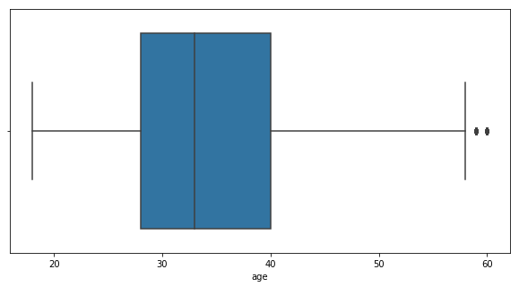

```python
# box plot of age variable without outliers
plt.figure(figsize=(10,5))
sb.boxplot(data = df_clean, x = 'age', color = base);
```

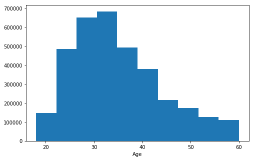

```python
# distribution by age with outliers already removed

plt.figure(figsize=[8, 5])
plt.hist(data = df_clean, x = 'age')
plt.xlabel('Age')
plt.show()
```

Moving on to the next numeric variable of the set - duration in minutes, I start with a box plot and a histogram. Both of the plots show extrime amount of outliers and right skwed data.

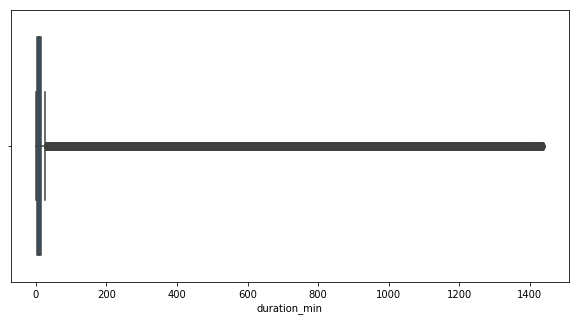

```python
# box plot of trip duration
plt.figure(figsize=(10,5))
sb.boxplot(data = df_clean, x = 'duration_min', color = base);
```

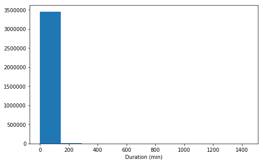

```python
# histogram of distributuion by trip duration
plt.figure(figsize=[8, 5])
plt.hist(data = df_clean, x = 'duration_min')
plt.xlabel('Duration (min)')
plt.show()
```

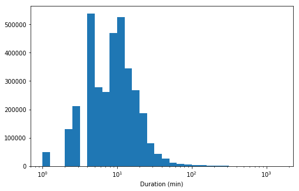

```python
# histogram of distribution of trip duration
plt.figure(figsize=[8, 5])
binedges = 10**np.arange(0, np.log10(df_clean['duration_min'].max())+0.1, 0.1)

plt.hist(data = df_clean , x = 'duration_min' , bins = binedges);
plt.xlabel('Duration (min)');
plt.xscale('log');
```

```python
# adjust dataset for trip duration under 40 min
df_duration_correct1 = df_clean[df_clean['duration_min'] <= 40]
```

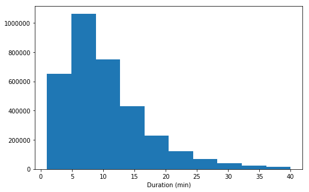

```python
# distribution of trip duration in minutes with trips less then 40 min

plt.figure(figsize=[8, 5])
plt.hist(data = df_duration_correct1, x = 'duration_min')
plt.xlabel('Duration (min)')
plt.show()
```

By limiting the dataset to arbitrary trip duration of 40 min, which sounds as a realistic duration of a bike trip, I have noticed the distribution remains highly right skwed. Below I used the box plot to remove the outliers completely which showed the maximum trip duration excluding outliers reaching about 30 min. The mean trip duration for the dataset is about 12 and a half minutes

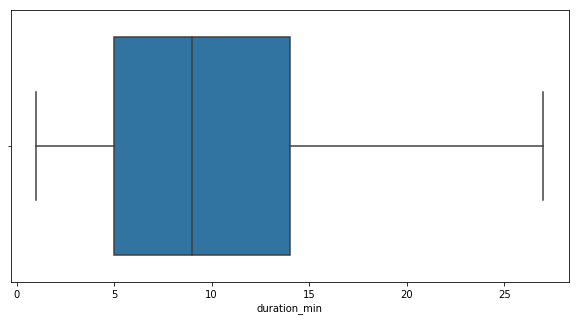

```python
# plot the same distribution but without outliers using "showfliers" argument
plt.figure(figsize=(10,5))
sb.boxplot(data = df_clean, x = 'duration_min',showfliers=False, color = base);
```

```python
# distribution of values for diration in minutes
df_clean.duration_min.describe()
```

```
count    3.460939e+06
mean     1.236753e+01
std      3.252183e+01
min      1.000000e+00
25%      5.000000e+00
50%      9.000000e+00
75%      1.400000e+01
max      1.438000e+03
Name: duration_min, dtype: float64
```

```python
# mean duration
df_clean.duration_min.mean()
```

```
12.367525402788088
```

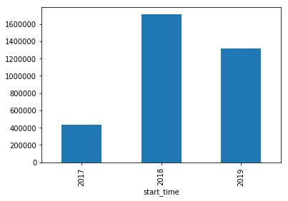

```python
# number of bike rides by year
df_clean.groupby(df_clean['start_time'].dt.year)['bike_id'].count().plot(kind="bar");
```

In order to explore number of bike rides acording to time variables available in the set I grouped the data by year and by year and month. The year of 2018 shows the most amount of bike rides and the 2017 is the least. However being aware that the dataset does not contain equal number of month for each year it is not the best way to guage the trend.

In my opinion ploting the line of distribution of bike rides along the whole available time frame allows for more accurate representation of data. I used groupby() by month and year and agg() function to aggregate based on bike id count as presented below.

```python
df_by_year = df_clean.groupby([df_clean['start_time'].dt.year.rename('year'), df_clean
                               ['start_time'].dt.month.rename('month')])
df_by_year.describe()
```

| year | month | bike_id count | bike_id mean | bike_id std | bike_id min | bike_id 25% | bike_id 50% | bike_id 75% | bike_id max | duration_sec count | duration_sec mean | ... | age 75% | age max | duration_min count | duration_min mean | duration_min std | duration_min min | duration_min 25% | duration_min 50% | duration_min 75% | duration_min max |
| --- | --- | --- | --- | --- | --- | --- | --- | --- | --- | --- | --- | --- | --- | --- | --- | --- | --- | --- | --- | --- | --- | --- |
| 2017 | 6 | 2252.0 | 507.333481 | 332.140018 | 13.0 | 210.0 | 434.0 | 819.25 | 1096.0 | 2252.0 | 794.467140 | ... | 47.0 | 60.0 | 2252.0 | 12.752664 | 40.514995 | 1.0 | 6.0 | 8.0 | 12.0 | 1176.0 |
|  | 7 | 34351.0 | 910.612733 | 695.057121 | 12.0 | 322.0 | 766.0 | 1273.00 | 2565.0 | 34351.0 | 972.480248 | ... | 45.0 | 60.0 | 34351.0 | 15.718291 | 52.647281 | 1.0 | 6.0 | 9.0 | 13.0 | 1417.0 |
|  | 8 | 67117.0 | 1578.818585 | 862.626545 | 12.0 | 805.0 | 1715.0 | 2333.00 | 2976.0 | 67117.0 | 911.657658 | ... | 44.0 | 60.0 | 67117.0 | 14.702966 | 51.403591 | 1.0 | 6.0 | 9.0 | 14.0 | 1435.0 |
|  | 9 | 82629.0 | 1687.167883 | 916.224947 | 11.0 | 860.0 | 1773.0 | 2519.00 | 3199.0 | 82629.0 | 875.254789 | ... | 44.0 | 60.0 | 82629.0 | 14.096879 | 44.089178 | 1.0 | 6.0 | 9.0 | 14.0 | 1432.0 |
|  | 10 | 91930.0 | 1782.153628 | 962.989935 | 11.0 | 973.0 | 1892.0 | 2652.00 | 3199.0 | 91930.0 | 792.579561 | ... | 43.0 | 60.0 | 91930.0 | 12.718122 | 38.480320 | 1.0 | 6.0 | 9.0 | 13.0 | 1426.0 |
|  | 11 | 83196.0 | 1738.384574 | 955.275327 | 10.0 | 906.0 | 1817.0 | 2603.00 | 3404.0 | 83196.0 | 770.246334 | ... | 42.0 | 60.0 | 83196.0 | 12.344500 | 34.707473 | 1.0 | 5.0 | 9.0 | 13.0 | 1437.0 |
|  | 12 | 75347.0 | 1964.493477 | 1057.827284 | 11.0 | 1082.0 | 2062.0 | 2906.00 | 3733.0 | 75347.0 | 764.899067 | ... | 43.0 | 60.0 | 75347.0 | 12.257754 | 36.552425 | 1.0 | 5.0 | 8.0 | 13.0 | 1432.0 |
| 2018 | 1 | 83771.0 | 2048.014014 | 1092.785193 | 11.0 | 1130.0 | 2151.0 | 3016.00 | 3744.0 | 83771.0 | 727.159924 | ... | 42.0 | 60.0 | 83771.0 | 11.627592 | 30.159138 | 1.0 | 5.0 | 8.0 | 13.0 | 1410.0 |
|  | 2 | 95287.0 | 2018.516135 | 1092.855594 | 11.0 | 1101.0 | 2113.0 | 2985.00 | 3747.0 | 95287.0 | 748.262176 | ... | 42.0 | 60.0 | 95287.0 | 11.979693 | 33.799383 | 1.0 | 5.0 | 8.0 | 13.0 | 1424.0 |
|  | 3 | 99205.0 | 2007.153470 | 1088.018714 | 11.0 | 1108.0 | 2084.0 | 2956.00 | 3756.0 | 99205.0 | 738.788257 | ... | 41.0 | 60.0 | 99205.0 | 11.821955 | 32.377030 | 1.0 | 5.0 | 8.0 | 13.0 | 1415.0 |
|  | 4 | 118362.0 | 2114.071662 | 1167.335224 | 11.0 | 1124.0 | 2183.0 | 3121.00 | 4073.0 | 118362.0 | 765.448176 | ... | 41.0 | 60.0 | 118362.0 | 12.267155 | 35.039141 | 1.0 | 5.0 | 8.0 | 13.0 | 1435.0 |
|  | 5 | 162745.0 | 2418.509226 | 1261.711445 | 11.0 | 1344.0 | 2582.0 | 3649.00 | 4231.0 | 162745.0 | 765.345848 | ... | 41.0 | 60.0 | 162745.0 | 12.263412 | 33.299312 | 1.0 | 5.0 | 8.0 | 13.0 | 1436.0 |
|  | 6 | 178605.0 | 2304.029579 | 1244.552390 | 11.0 | 1243.0 | 2409.0 | 3405.00 | 4307.0 | 178605.0 | 822.628146 | ... | 40.0 | 60.0 | 178605.0 | 13.219602 | 38.151390 | 1.0 | 5.0 | 9.0 | 14.0 | 1421.0 |
|  | 7 | 182492.0 | 2252.809225 | 1228.252526 | 11.0 | 1203.0 | 2335.0 | 3326.00 | 4307.0 | 182492.0 | 838.488208 | ... | 39.0 | 60.0 | 182492.0 | 13.483939 | 36.988793 | 1.0 | 5.0 | 9.0 | 14.0 | 1423.0 |
|  | 8 | 176962.0 | 2191.046626 | 1208.386584 | 11.0 | 1181.0 | 2244.0 | 3182.00 | 4466.0 | 176962.0 | 804.904516 | ... | 40.0 | 60.0 | 176962.0 | 12.923888 | 35.835957 | 1.0 | 5.0 | 9.0 | 14.0 | 1432.0 |
|  | 9 | 172655.0 | 2408.112942 | 1314.227665 | 11.0 | 1308.0 | 2464.0 | 3496.00 | 4465.0 | 172655.0 | 814.314210 | ... | 40.0 | 60.0 | 172655.0 | 13.080009 | 33.947594 | 1.0 | 5.0 | 9.0 | 14.0 | 1438.0 |
|  | 10 | 188842.0 | 2312.924741 | 1287.021145 | 11.0 | 1235.0 | 2327.0 | 3378.00 | 4464.0 | 188842.0 | 757.018460 | ... | 39.0 | 60.0 | 188842.0 | 12.124771 | 28.115692 | 1.0 | 5.0 | 9.0 | 14.0 | 1436.0 |
|  | 11 | 125946.0 | 2210.067823 | 1250.568924 | 11.0 | 1184.0 | 2184.0 | 3220.00 | 4464.0 | 125946.0 | 717.675178 | ... | 39.0 | 60.0 | 125946.0 | 11.469495 | 27.057172 | 1.0 | 5.0 | 8.0 | 13.0 | 1433.0 |
|  | 12 | 123378.0 | 3192.474047 | 1698.558164 | 11.0 | 1705.0 | 3283.0 | 4827.00 | 6234.0 | 123378.0 | 732.592593 | ... | 40.0 | 60.0 | 123378.0 | 11.718094 | 25.083762 | 1.0 | 5.0 | 8.0 | 13.0 | 1433.0 |
| 2019 | 1 | 178681.0 | 4054.223958 | 1558.829166 | 11.0 | 3158.0 | 4755.0 | 5178.00 | 6638.0 | 178681.0 | 715.207879 | ... | 39.0 | 60.0 | 178681.0 | 11.428311 | 25.707621 | 1.0 | 5.0 | 8.0 | 13.0 | 1400.0 |
|  | 2 | 171617.0 | 4489.467296 | 1655.147492 | 11.0 | 3826.0 | 4963.0 | 5506.00 | 6645.0 | 171617.0 | 703.440492 | ... | 38.0 | 60.0 | 171617.0 | 11.232040 | 27.568324 | 1.0 | 5.0 | 8.0 | 13.0 | 1409.0 |
|  | 3 | 239983.0 | 4947.497989 | 1664.734409 | 11.0 | 4557.0 | 5387.0 | 6134.00 | 7082.0 | 239983.0 | 777.876520 | ... | 38.0 | 60.0 | 239983.0 | 12.473871 | 31.347654 | 1.0 | 5.0 | 8.0 | 14.0 | 1415.0 |
|  | 4 | 223751.0 | 3686.054194 | 2181.348924 | 11.0 | 1744.0 | 3505.0 | 5767.00 | 7108.0 | 223751.0 | 770.536950 | ... | 38.0 | 60.0 | 223751.0 | 12.351346 | 30.305543 | 1.0 | 5.0 | 9.0 | 14.0 | 1435.0 |
|  | 5 | 169808.0 | 1967.181199 | 1138.508705 | 12.0 | 1024.0 | 1932.0 | 2983.00 | 7196.0 | 169808.0 | 749.059114 | ... | 39.0 | 60.0 | 169808.0 | 11.993181 | 26.201452 | 1.0 | 5.0 | 9.0 | 14.0 | 1416.0 |
|  | 6 | 168985.0 | 9003.485795 | 61782.484275 | 12.0 | 1022.0 | 1926.0 | 2965.00 | 985110.0 | 168985.0 | 763.273083 | ... | 38.0 | 60.0 | 168985.0 | 12.230026 | 26.471840 | 1.0 | 6.0 | 9.0 | 14.0 | 1432.0 |
|  | 7 | 163042.0 | 65001.516168 | 179930.216070 | 12.0 | 1154.0 | 2228.0 | 3366.00 | 996963.0 | 163042.0 | 710.319280 | ... | 38.0 | 60.0 | 163042.0 | 11.346328 | 23.453329 | 1.0 | 5.0 | 9.0 | 13.0 | 1384.0 |

26 rows × 88 columns

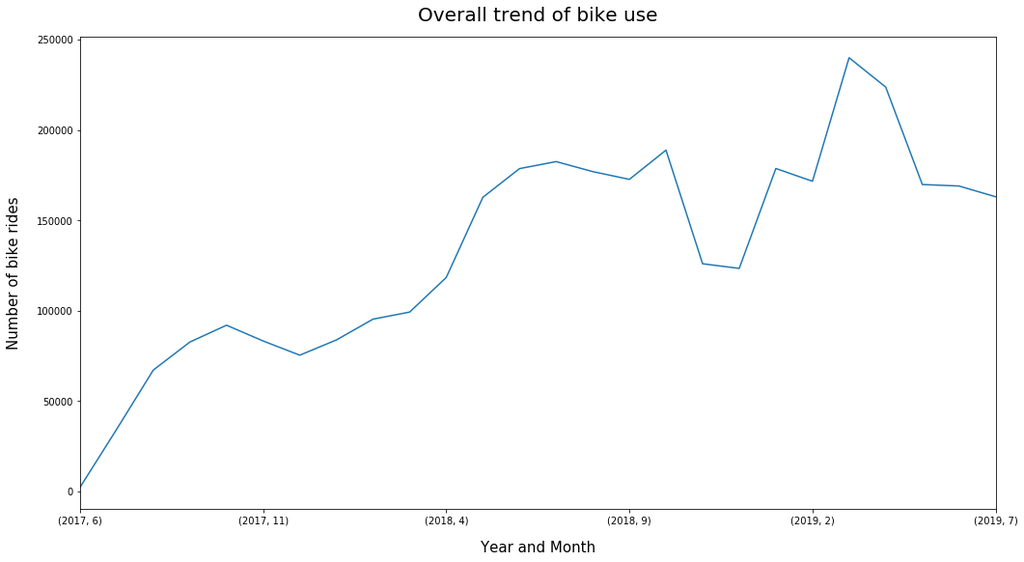

```python
# overall growth of bike use
df_by_year.agg({'bike_id':'count'}).plot(style='-', legend=False, figsize=(17,9));
plt.title('Overall trend of bike use', fontsize=20,  y=1.02)
plt.xlabel('Year and Month',labelpad=16, fontsize=15)
plt.ylabel('Number of bike rides',labelpad=16, fontsize=15);
```

On the contrary to previous plot, the line plot shows that bike usage actually spiked to the highest amount in around of March 2019 preceded and followed by sharp declined.